# BANA 7050: Assignment 3

#### Change Points Analysis:

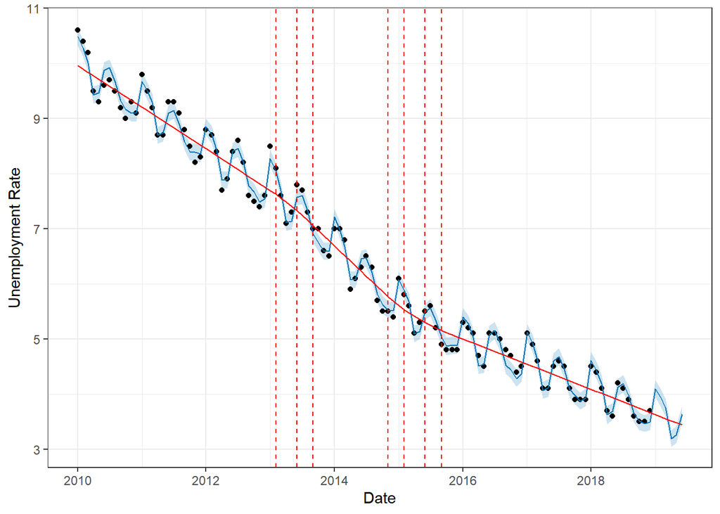

```r
plot(best_mod,orig_forecast)+add_changepoints_to_plot(best_mod)+theme_bw()+xlab("Date")+ylab("Unemployment Rate")
```

1. A few change points are identified in the trend part by the Prophet model
2. These change points seem to be reasonable. The slope/inclination of trend component of our time series changes slightly near the change points
3. Additionally, the almost constant decline in the forecast trend suggests us to consider setting cap/floor and logistic trend
4. Hence, we update the model hyperparameters by setting the appropriate values of floor/cap, growth trend type and number of change points

#### Change Points Analysis: Tuned Hyperparameters

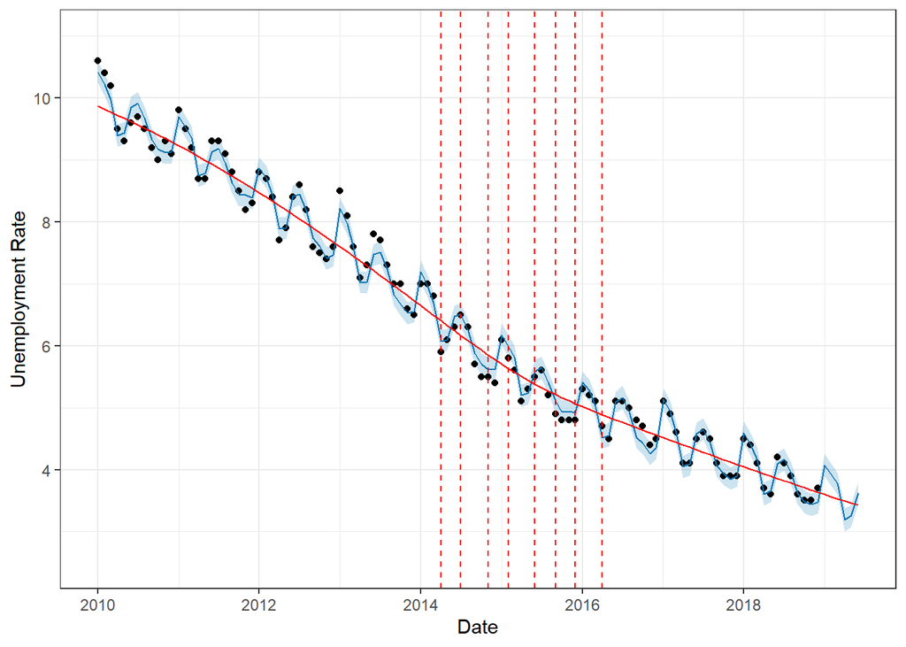

```r
# Set "floor" in training data
prophet_data$floor = 0
prophet_data$cap = 12
orig_future$floor = 0
orig_future$cap = 12

sat_model = prophet::prophet(prophet_data,growth ='logistic')
forecast = predict(sat_model,orig_future)
plot(sat_model,forecast)+add_changepoints_to_plot(sat_model)+theme_bw()+xlab("Date")+ylab("Unemployment Rate") +ylim(2.5,11)
```

1. The **floor of 0** and **cap of 12**, **25 change points** (defalut value) and **logistic growth trend** seem to be optimum choice of hyperparamters